# Comparación de Distribuciones Poblacionales y Muestrales

Análisis de la variable ‘Peso_NA’

David Andres Quintela Saavedra

2025-11-13

# 1. Cargar Paquetes

Primero, cargamos los paquetes que usaremos para el análisis.

tidyverse: Para la manipulación de datos (dplyr) y gráficos (ggplot2).

knitr: Para mostrar tablas de forma ordenada (kable()).

```r
library(tidyverse)
library(knitr)
```

# 2. Carga y Limpieza de Datos

Para este análisis, partimos de los mismos datos de ventas de videojuegos. Realizaremos el mismo proceso de limpieza que definimos en el reporte anterior.

## 2.1 Carga de Datos

```r
# Lee los datos desde la carpeta 'data' en la raíz del proyecto
sales_data <- read.csv(here::here("data", "vgsales.csv"))
```

## 2.2 Limpieza y Conversión

Aquí realizamos el proceso de limpieza y conversión de tipos que ya investigamos:

Filtramos el texto “N/A” de la columna Year.

Convertimos Year a numérico y filtramos NAs y años < 1990.

Convertimos las variables categóricas a factor.

```r
sales_data_clean <- sales_data %>%
  # Limpieza de 'Year'
  filter(Year != "N/A") %>%
  mutate(Year = as.numeric(as.character(Year))) %>%
  filter(!is.na(Year), Year >= 1990) %>%

  # Conversión de Tipos
  mutate(
    Platform  = as.factor(Platform),
    Genre     = as.factor(Genre),
    Publisher = as.factor(Publisher)
  )

cat(sprintf("El conjunto de datos limpios contiene %d registros.\n", nrow(sales_data_clean)))
```

```
## El conjunto de datos limpios contiene 16122 registros.
```

# 3. Definición de la Población y Variable de Interés

Aquí comienzan los pasos específicos para esta tarea.

## 3.1 Creación de la Población

Las instrucciones nos piden definir nuestra “población de interés” como todos los juegos con ventas globales (Global_Sales) menores a 2 millones.

```r
poblacion <- sales_data_clean %>%
  filter(Global_Sales < 2)

cat(sprintf("Nuestra población de interés (juegos < 2M en ventas) tiene %d registros.", nrow(poblacion)))
```

```
## Nuestra población de interés (juegos < 2M en ventas) tiene 15318 registros.
```

## 3.2 Creación de la Variable Peso_NA

Ahora, creamos la nueva variable Peso_NA, que mide el porcentaje de las ventas de Norteamérica (NA_Sales) sobre el total (Global_Sales).

Importante: Filtraremos cualquier fila donde Global_Sales sea 0 para evitar errores de división por cero (NaN).

```r
poblacion <- poblacion %>%
  filter(Global_Sales > 0) %>% # Prevenir división por cero
  mutate(Peso_NA = (NA_Sales / Global_Sales))

# Verificamos los resultados
cat("Resumen estadístico de la nueva variable 'Peso_NA':\n")
```

```
## Resumen estadístico de la nueva variable 'Peso_NA':
```

```r
summary(poblacion$Peso_NA)
```

```
##    Min. 1st Qu.  Median    Mean 3rd Qu.    Max.
##  0.0000  0.0000  0.5000  0.4495  0.7500  1.0000
```

## 3.3 Distribución de la Población

Veamos cómo se distribuye nuestra nueva variable Peso_NA en toda la población.

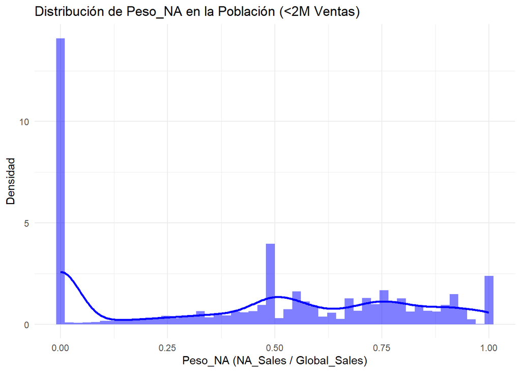

```r
ggplot(poblacion, aes(x = Peso_NA)) +
  geom_histogram(aes(y = ..density..), bins = 50, fill = "blue", alpha = 0.5) +
  geom_density(color = "blue", linewidth = 1) +
  labs(title = "Distribución de Peso_NA en la Población (<2M Ventas)",
       x = "Peso_NA (NA_Sales / Global_Sales)",
       y = "Densidad") +
  theme_minimal()
```

### Observación de la Población:

La distribución está fuertemente sesgada. Vemos dos picos claros:

Un pico muy grande en 0, que representa juegos que no tuvieron ventas en Norteamérica.

Un pico más pequeño cerca de 1, que representa juegos cuyas ventas fueron casi exclusivamente en Norteamérica.

Una gran masa de juegos se concentra entre 0.25 y 0.75.

# 4. Muestreo y Comparación

Las instrucciones nos piden tomar dos muestras aleatorias de tamaño 500 para compararlas con la población.

## 4.1 Toma de Muestras

Usamos set.seed() para asegurar que nuestro análisis sea reproducible (que siempre obtengamos las mismas muestras).

```r
# Fijamos una semilla para la primera muestra
set.seed(123)
muestra_1 <- poblacion %>%
  sample_n(500)

# Fijamos una semilla DIFERENTE para la segunda muestra
set.seed(456)
muestra_2 <- poblacion %>%
  sample_n(500)

cat(sprintf("Muestra 1: %d registros\n", nrow(muestra_1)))
```

```
## Muestra 1: 500 registros
```

```r
cat(sprintf("Muestra 2: %d registros\n", nrow(muestra_2)))
```

```
## Muestra 2: 500 registros
```

## 4.2 Comparación de Estadísticas Básicas

Comparemos las estadísticas descriptivas (media, mediana, etc.) de nuestras dos muestras con las de la población completa.

```r
# 1. Obtener estadísticas (esto está bien)
stats_poblacion <- summary(poblacion$Peso_NA)
stats_muestra_1 <- summary(muestra_1$Peso_NA)
stats_muestra_2 <- summary(muestra_2$Peso_NA)

# 2. Combinar los sumarios como FILAS usando rbind()
tabla_comparativa <- rbind(
  Poblacion = stats_poblacion,
  Muestra_1 = stats_muestra_1,
  Muestra_2 = stats_muestra_2
)

# 3. Mostrar la tabla con kable()
kable(tabla_comparativa, digits = 4)
```

|  | Min. | 1st Qu. | Median | Mean | 3rd Qu. | Max. |
| --- | --- | --- | --- | --- | --- | --- |
| Poblacion | 0 | 0 | 0.5 | 0.4495 | 0.7500 | 1 |
| Muestra_1 | 0 | 0 | 0.5 | 0.4431 | 0.7500 | 1 |
| Muestra_2 | 0 | 0 | 0.5 | 0.4630 | 0.7423 | 1 |

### Observación de Estadísticas:

Como podemos ver en la tabla, las estadísticas de ambas muestras son extremadamente similares a las de la población. La Mean (Media) y Median (Mediana) están muy cercanas, lo que sugiere que nuestras muestras son buenas representantes de la población general.

## 4.3 Comparación Gráfica de Distribuciones

La mejor forma de comparar las distribuciones es graficarlas juntas. Usaremos gráficos de densidad.

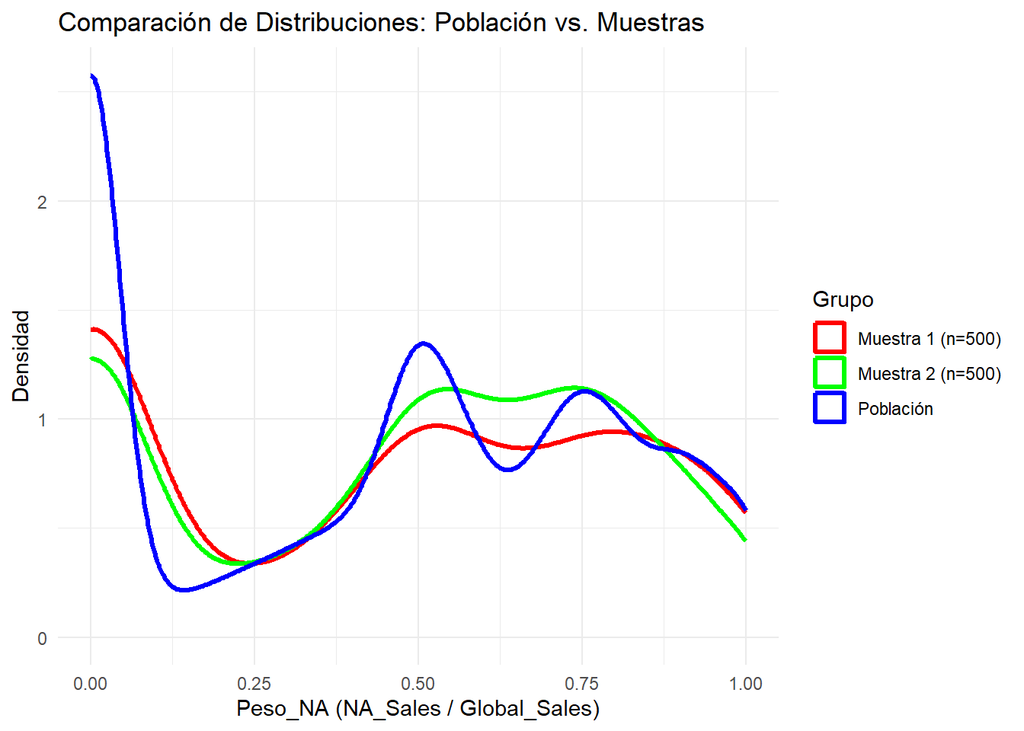

```r
# 1. Creamos un solo dataframe para graficar
datos_comparativos <- bind_rows(
  poblacion %>% select(Peso_NA) %>% mutate(Grupo = "Población"),
  muestra_1 %>% select(Peso_NA) %>% mutate(Grupo = "Muestra 1 (n=500)"),
  muestra_2 %>% select(Peso_NA) %>% mutate(Grupo = "Muestra 2 (n=500)")
)

# 2. Graficamos las densidades
ggplot(datos_comparativos, aes(x = Peso_NA, color = Grupo)) +
  geom_density(linewidth = 1.1) +
  labs(title = "Comparación de Distribuciones: Población vs. Muestras",
       x = "Peso_NA (NA_Sales / Global_Sales)",
       y = "Densidad") +
  theme_minimal() +
  scale_color_manual(values = c("Población" = "blue",
                                "Muestra 1 (n=500)" = "red",
                                "Muestra 2 (n=500)" = "green"))
```

# 5. Conclusiones y Observaciones

Representatividad: Las dos muestras aleatorias (Muestra 1 y Muestra 2) han demostrado ser excelentes representantes de la población de interés (Global_Sales < 2M).

Estadísticas: Las estadísticas descriptivas clave (como la media y la mediana) de las muestras están muy alineadas con las de la población.